# Lab #14 - Submission

May 1, 2024

```r
library(sf)
library(terra)
library(terrainr)
```

```r
library(dplyr, warn.conflicts = F)
library(tidyr, warn.conflicts = F) # For replace_na()
library(ggplot2)
options(stringsAsFactors = F)
```

**Download the required datasets:**

- Montana_DEM_1992_250m.tiff
- GlacierNatPark_vector_data.zip (Unzip three Shapefiles)
- Gonzalez_National_Park_climate_data.zip (Unzip one Shapefile, three GeoTIFFs)

The data on projected temperature, precipitation changes in CONUS comes from [a study on historical and future changes in America’s National Parks.](https://irma.nps.gov/DataStore/Reference/Profile/2266988)

## Overview

### Combining Raster and Vector Data

Vector datasets can be opened using the `terra` library as well, though they will have a different representation than when opened with `sf`.

```r
with.sf <- st_read('data/GlacierNatPark_vector_data/GlacierNatPark_boundary_UTM.shp')
with.terra <- vect('data/GlacierNatPark_vector_data/GlacierNatPark_boundary_UTM.shp')
```

```r
class(with.sf)
```

```
## [1] "sf"         "data.frame"
```

```r
class(with.terra)
```

```
## [1] "SpatVector"
## attr(,"package")
## [1] "terra"
```

Certain functions in `terra` only work with `SpatVector` and not with an `sf::data.frame`.

**But any `sf::data.frame` can be turned into an `terra::SpatVector` using the `vect()` function:**

```r
thing <- vect(with.sf)
class(thing)
```

```
## [1] "SpatVector"
## attr(,"package")
## [1] "terra"
```

### Reading in Data

```r
boundary <- st_read('data/GlacierNatPark_vector_data/GlacierNatPark_boundary_UTM.shp')
roads <- st_read('data/GlacierNatPark_vector_data/NPS_GlacierNatPark_roads_NAD83.shp')
trails <- st_read('data/GlacierNatPark_vector_data/NPS_GlacierNatPark_trails_NAD83.shp')
# Both the Roads and Trails layers are 4-dimensional vector data (XYZM)!
#    We need them to be 2-dimensional (XY), so we drop the "ZM" coordinates.
roads <- st_zm(roads)
trails <- st_zm(trails)

# There shouldn't be NA values in a character string column; use empty string, "", instead
roads <- roads %>%
  replace_na(list(RDNAME = ''))
```

## Problem 14.1 - Clipping and Projecting a Raster

1. Project the DEM raster to [the UTM 12 N coordinate reference system (CRS)](https://epsg.io/26912), same as the `boundary` data.
2. Clip *and mask* the DEM raster to the Park `boundary`. Pixels outside the `boundary` should be masked.
3. Convert the data from meters to feet.
4. Plot the result.

**Hint:** The `terra` `crs()` function can also be used with vector data.

**Hint:** You’ll need to use `terra` library’s `crop()` function, with the argument `mask = TRUE`, to crop and mask the DEM raster to the Park `boundary`. Read about the `crop()` function using: `help(crop)`.

## Solution 14.1

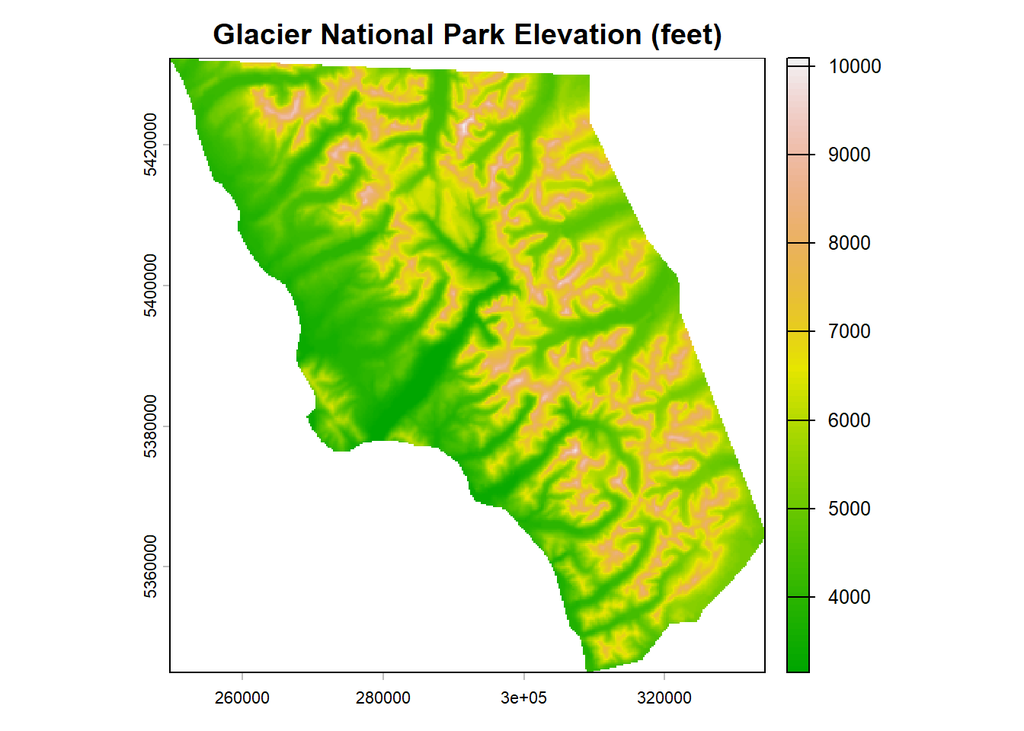

```r
# 1) Reproject DEM to boundary's crs (UTM Z12N)
dem <- rast('data/Montana_DEM_1992_250m.tiff')
dem.utm <- project(dem, crs(vect(boundary)))

# 2) clip to GNP boundary boundary
dem.gnp <- crop(dem.utm, vect(boundary), mask = TRUE)

# 3) Convert meters to feet
dem.gnp.feet <- dem.gnp * 3.28084

# 4) Plot the final clipped DEM
plot(dem.gnp.feet, col = terrain.colors(100), main = 'Glacier National Park Elevation (feet)')
```

## Problem 14.2 - Mapping Glacier National Park

Using the clipped, projected, and converted DEM from the previous problem… **Create a map of Glacier National Park that shows:**

- All Park roads, `NPS_GlacierNatPark_roads_NAD83.shp` or `roads`
- All Park trails, `NPS_GlacierNatPark_trails_NAD83.shp` or `trails`
- The “Going-to-the-Sun” road should be styled differently from other roads, with a legend entry distinguishing the road from all other Park roads.

The map should be displayed in the NAD83 UTM 12 N coordinate system (same as `boundary`).

**Some advice on making your map prettier:** Line width of POLYGON features in `geom_sf()` is controlled by the `lwd` aesthetic and **not** the `size` aesthetic; e.g.: `geom_sf(data = something, lwd = 2)`

## Solution 14.2

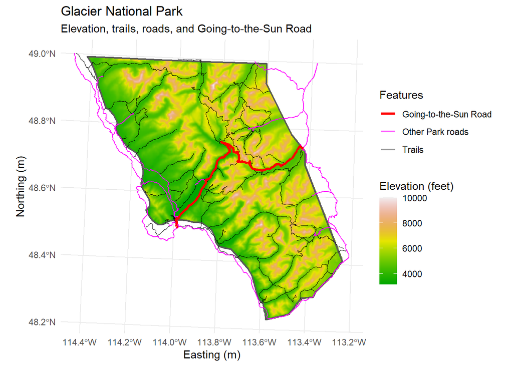

```r
# Prepare the DEM from Problem 14.1 for mapping with ggplot2
dem.gnp.df <- as.data.frame(dem.gnp.feet, xy = TRUE)
names(dem.gnp.df)[3] <- 'elevation_ft'

# Project roads and trails to NAD83 / UTM Zone 12N, matching boundary
roads.utm <- st_transform(roads, st_crs(boundary))
trails.utm <- st_transform(trails, st_crs(boundary))

# Separate Going-to-the-Sun Road from all other Park roads
going.to.the.sun <- roads.utm %>%
  filter(RDNAME == 'Going-to-the-Sun Road')

other.roads <- roads.utm %>%
  filter(RDNAME != 'Going-to-the-Sun Road')

# Map Glacier National Park with elevation, trails, roads, and a road legend
ggplot() +
  geom_raster(
    data = dem.gnp.df,
    aes(x = x, y = y, fill = elevation_ft)
  ) +
  geom_sf(data = boundary, fill = NA, color = 'gray35', lwd = 0.8) +
  geom_sf(
    data = trails.utm,
    aes(color = 'Trails'),
    lwd = 0.25,
    alpha = 0.8
  ) +
  geom_sf(
    data = other.roads,
    aes(color = 'Other Park roads'),
    lwd = 0.45
  ) +
  geom_sf(
    data = going.to.the.sun,
    aes(color = 'Going-to-the-Sun Road'),
    lwd = 1.1
  ) +
  scale_fill_gradientn(
    name = 'Elevation (feet)',
    colors = terrain.colors(100)
  ) +
  scale_color_manual(
    name = 'Features',
    values = c(
      'Going-to-the-Sun Road' = 'red',
      'Other Park roads' = 'magenta',
      'Trails' = 'black'
    )
  ) +
  coord_sf(crs = st_crs(boundary)) +
  labs(
    title = 'Glacier National Park',
    subtitle = 'Elevation, trails, roads, and Going-to-the-Sun Road',
    x = 'Easting (m)',
    y = 'Northing (m)'
  ) +
  theme_minimal()
```

## Future Changes in America’s National Parks

The Gonzalez et al. (2018) study analyzed future temperature and precipitation in America’s National Parks.

- `data/Gonzalez_National_Park_climate_data/Gonzalez_temp_proj_CONUS_26_trend_resampled.tif`: Projected temperature trends (deg C per 100 years) through 2100 under RCP 2.6
- `data/Gonzalez_National_Park_climate_data/Gonzalez_temp_proj_CONUS_85_trend_resampled.tif`: Projected temperature trends (deg C per 100 years) through 2100 under RCP 8.5
- `data/Gonzalez_National_Park_climate_data/Gonzalez_temp_proj_CONUS_26_vel_resampled.tif`: The *climate velocity* (km per year) under RCP 2.6

Boundaries for America’s National Parks are provided as the `data/Gonzalez_National_Park_climate_data/Gonzalez_National_Park_boundaries.shp` Shapefile inside `data/Gonzalez_National_Park_climate_data`.

## Problem 14.3 - Temperature Trends

Plot the temperature trends in each of these seven (7) National Parks:

```r
seven.parks <- c('Olympic National Park', 'Everglades National Park', 'Yellowstone National Park', 'Joshua Tree National Park', 'Yosemite National Park', 'Big Bend National Park', 'Glacier National Park')
```

**You might choose to show this as a bar plot, where the height/ length of the bar corresponds to the temperature trend through 2100. Show temperature trends for both scenarios** (RCP 2.6 and RCP 8.5) **on a single plot, using either facets or dodged bars.**

**Hint:** You will need to use the `zonal()` function. [Read about it here.](https://rspatial.github.io/terra/reference/zonal.html)

**Hint:** You can bind two data frames together using [`bind_cols()`](https://dplyr.tidyverse.org/reference/bind_cols.html) or [`bind_rows()`](https://dplyr.tidyverse.org/reference/bind_rows.html). Or, you can just create a new data frame from vectors:

```r
data.frame(some.column = other.df$ColumnA, another.column = other.df$ColumnB)
```

**Hint:** The `tidyr` function `gather()` might also help, to combine the data from different scenarios into a single column; this can make plotting easier in `ggplot2`.

## Solution 14.3

```r
# Create the vector of the seven National Parks listed in the question
seven.parks <- c(
  'Olympic National Park',
  'Everglades National Park',
  'Yellowstone National Park',
  'Joshua Tree National Park',
  'Yosemite National Park',
  'Big Bend National Park',
  'Glacier National Park'
)

# Read the National Park boundaries and the two temperature trend rasters
parks <- st_read('data/Gonzalez_National_Park_climate_data/Gonzalez_National_Park_boundaries.shp')
```

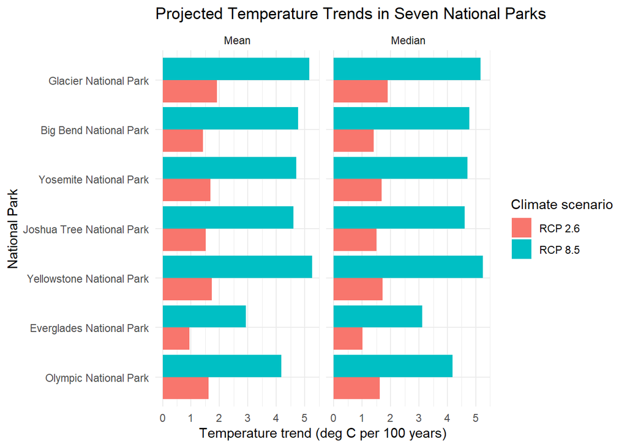

```r
temp.26 <- rast('data/Gonzalez_National_Park_climate_data/Gonzalez_temp_proj_CONUS_26_trend_resampled.tif')
temp.85 <- rast('data/Gonzalez_National_Park_climate_data/Gonzalez_temp_proj_CONUS_85_trend_resampled.tif')

# Keep only the seven National Parks listed in the question
seven.parks.sf <- parks %>%
  filter(NAME %in% seven.parks) %>%
  mutate(NAME = factor(NAME, levels = seven.parks)) %>%
  arrange(NAME)

# Project the Park boundaries to match the temperature rasters before using zonal()
seven.parks.vect <- vect(seven.parks.sf)
seven.parks.vect <- project(seven.parks.vect, crs(temp.26))

# Rasterize the Park NUMBER field so zonal() returns results by Park ID
park.zones <- rasterize(seven.parks.vect, temp.26, field = 'NUMBER')
names(park.zones) <- 'NUMBER'

# Calculate mean and median temperature trends for each Park and scenario
temp.26.mean <- zonal(temp.26, park.zones, fun = 'mean', na.rm = TRUE)
temp.26.median <- zonal(temp.26, park.zones, fun = 'median', na.rm = TRUE)
temp.85.mean <- zonal(temp.85, park.zones, fun = 'mean', na.rm = TRUE)
temp.85.median <- zonal(temp.85, park.zones, fun = 'median', na.rm = TRUE)

# Combine the zonal summaries and join them back to Park names by NUMBER
temp.trends <- bind_rows(
  data.frame(NUMBER = temp.26.mean$NUMBER, Scenario = 'RCP 2.6', Statistic = 'Mean',
             Temperature_trend = temp.26.mean[[2]]),
  data.frame(NUMBER = temp.26.median$NUMBER, Scenario = 'RCP 2.6', Statistic = 'Median',
             Temperature_trend = temp.26.median[[2]]),
  data.frame(NUMBER = temp.85.mean$NUMBER, Scenario = 'RCP 8.5', Statistic = 'Mean',
             Temperature_trend = temp.85.mean[[2]]),
  data.frame(NUMBER = temp.85.median$NUMBER, Scenario = 'RCP 8.5', Statistic = 'Median',
             Temperature_trend = temp.85.median[[2]])
) %>%
  left_join(st_drop_geometry(seven.parks.sf) %>% select(NUMBER, NAME), by = 'NUMBER') %>%
  mutate(Park = factor(NAME, levels = seven.parks))

# Plot both scenarios and both summary statistics
ggplot(temp.trends, aes(x = Park, y = Temperature_trend, fill = Scenario)) +
  geom_col(position = 'dodge') +
  coord_flip() +
  facet_wrap(~ Statistic) +
  labs(
    title = 'Projected Temperature Trends in Seven National Parks',
    x = 'National Park',
    y = 'Temperature trend (deg C per 100 years)',
    fill = 'Climate scenario'
  ) +
  theme_minimal()
```

## Problem 14.4 - Climate Velocity

Climate velocity (km per year) is “the instantaneous local velocity along Earth’s surface needed to maintain constant temperatures” [(Loarie et al. 2009)](https://www.nature.com/articles/nature08649). **In other words, how fast do organisms need to travel in order to maintain a constant-temperature environment for themselves?**

**Is there a relationship between climate velocity and latitude?** Use the `parks` vector dataset to answer this question. Can you find representative longitude-latitude coordinates (e.g., centroid) for each National Park?

**Hint:** The `st_coordinates()` function will give you an XY-coordinate pair, if you have a POINT geometry. **Ensure that you use `group_by(NUMBER)` if you’re going to use `st_coordinates()`, so that it is applied separately to each Park (each row).**

## Solution 14.4

```r
# Read the parks dataset if it has not already been created
if (!exists('parks')) {
  parks <- st_read('data/Gonzalez_National_Park_climate_data/Gonzalez_National_Park_boundaries.shp')
}

# Read the climate velocity raster
climate.velocity <- rast('data/Gonzalez_National_Park_climate_data/Gonzalez_temp_proj_CONUS_26_vel_resampled.tif')

# Find representative longitude-latitude coordinates for each Park
# Centroids are calculated in the projected raster CRS, then transformed back to NAD83 lon-lat
park.centroids <- parks %>%
  st_transform(crs(climate.velocity)) %>%
  st_centroid() %>%
  st_transform(st_crs(parks))
```

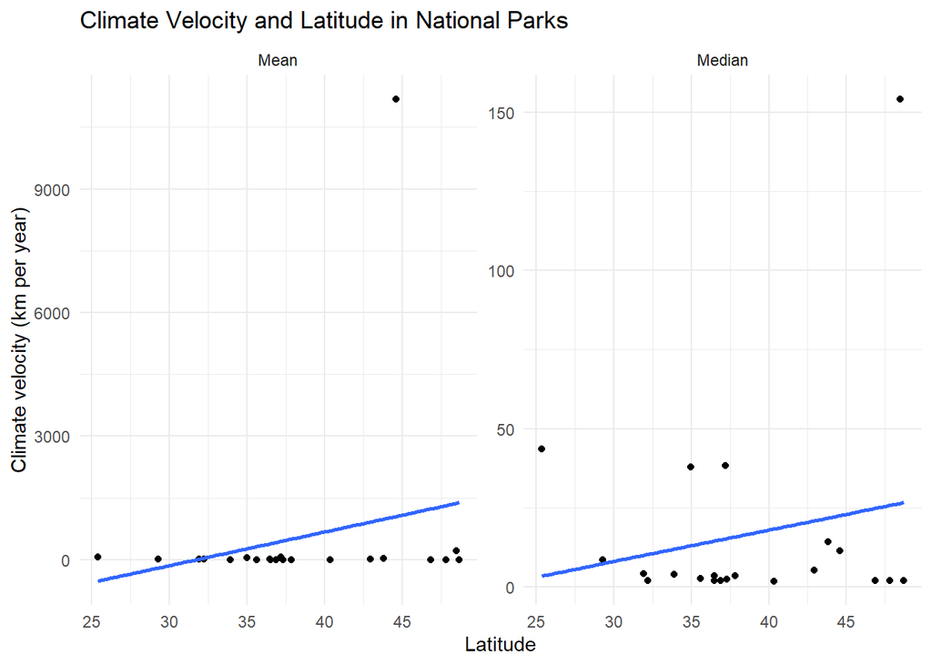

```r
park.coords <- park.centroids %>%
  group_by(NUMBER) %>%
  mutate(
    longitude = st_coordinates(geometry)[, 1],
    latitude = st_coordinates(geometry)[, 2]
  ) %>%
  st_drop_geometry() %>%
  ungroup()

# Project Park boundaries to match the climate velocity raster before using zonal()
parks.velocity.vect <- vect(parks)
parks.velocity.vect <- project(parks.velocity.vect, crs(climate.velocity))

# Rasterize the Park NUMBER field so zonal() returns results by Park ID
velocity.zones <- rasterize(parks.velocity.vect, climate.velocity, field = 'NUMBER')
names(velocity.zones) <- 'NUMBER'

# Calculate mean and median climate velocity for each Park
velocity.mean <- zonal(climate.velocity, velocity.zones, fun = 'mean', na.rm = TRUE)
velocity.median <- zonal(climate.velocity, velocity.zones, fun = 'median', na.rm = TRUE)

# Join the zonal summaries back to the Park coordinates by NUMBER
velocity.by.latitude <- bind_rows(
  data.frame(NUMBER = velocity.mean$NUMBER, Statistic = 'Mean',
             climate_velocity = velocity.mean[[2]]),
  data.frame(NUMBER = velocity.median$NUMBER, Statistic = 'Median',
             climate_velocity = velocity.median[[2]])
) %>%
  left_join(park.coords, by = 'NUMBER')

# Plot climate velocity against latitude to look for a relationship
ggplot(velocity.by.latitude, aes(x = latitude, y = climate_velocity)) +
  geom_point() +
  geom_smooth(method = 'lm', se = FALSE) +
  facet_wrap(~ Statistic, scales = 'free_y') +
  labs(
    title = 'Climate Velocity and Latitude in National Parks',
    x = 'Latitude',
    y = 'Climate velocity (km per year)'
  ) +
  theme_minimal()
```

```r
# Quantify the relationship with a simple linear model for each statistic
velocity.models <- bind_rows(lapply(split(velocity.by.latitude, velocity.by.latitude$Statistic), function(x) {
  model <- lm(climate_velocity ~ latitude, data = x)
  data.frame(
    Statistic = x$Statistic[1],
    slope = coef(model)[['latitude']],
    r_squared = summary(model)$r.squared,
    p_value = summary(model)$coefficients['latitude', 'Pr(>|t|)']
  )
}))

velocity.models
```

```
##   Statistic      slope  r_squared   p_value
## 1      Mean 81.6500824 0.04747465 0.3427174
## 2    Median  0.9943679 0.03570210 0.4120536
```

Based on the model table and scatterplots, there does not appear to be a strong relationship between climate velocity and latitude among the National Parks. Both the mean and median regressions have low R-squared values and non-significant p-values, meaning latitude explains very little of the variation in climate velocity.